# Quality Assurance - Rules of Thumb

# 1 Learning Objectives

After this module you will:

- Understand common challenges in predictive modelling
- Understand how common challenges can lead to appropriate quality assurance
- Be aware of:
  - The impact of data size and quality
  - The effect of model simplicity
  - Why no one model is optimal
  - How predictions can be gamed

# 2 Rules of Thumb

In the fields of predictive modelling, machine learning and statistics there are some “rules of thumb” which are known among practitioners.

These rules of thumb are a useful starting point for both understanding challenges in predictive modelling, and how we as the analytical assurer can check the quality of modelling systems.

In this module we will examine some common scenarios in predictive modelling, looking at the trade-offs between options, and how we can ask impactful questions using these common problems.

While we will not be able to ask highly detailed technical questions as a result of this module, we will be able to sense check a system at a high level.

The reason we are including these, quite specific analytical concepts, is because there is often an asymetric relationship between the model analyst, commissoner and end user.

Modelling analysts (hopefully!) should be aware of all of the concepts discussed, and will understand the impact they have on the system.

However, it is unlikely that the end user of a system or the person who requested the system creation will know about these concepts. Their interests and expertise will be elsewhere. It is therefore crucial that the analyst and assurer are able to communicate how these concepts impact the system to both each other, the model commissioner and users.

# 3 Quantity of Data

The first rule of thumb that we are going to examine is:

> “Training a model with more data will improve the model”

This is quite general, and has some caveats so we are going to break down what this means.

## 3.1 More Data

In order to train a statistical/machine learning model we give it training data.

Each record (data point) contains: features (some measurement), and a label. Our goal is to learn a model that, given some new data point’s features, predicts an appropriate label.

To do this well we need many data points.

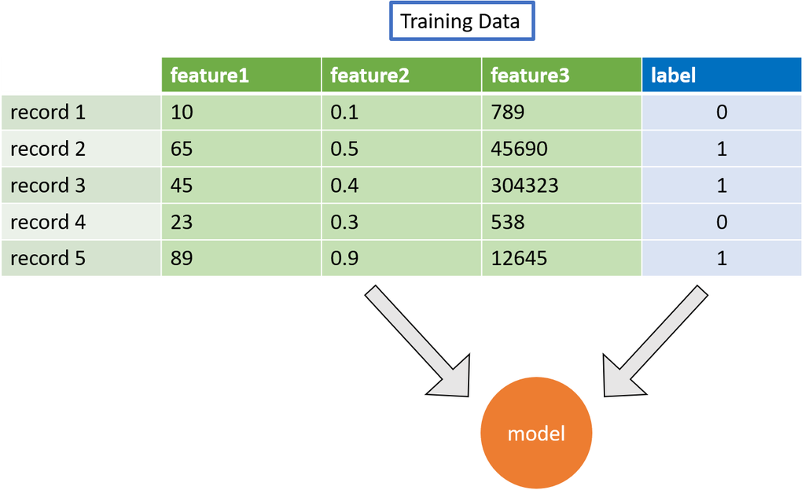

Figure 2.1: The model created by training the learning algorithm on the training data with known labels.

More data can broadly mean one of two things:

- more samples in our data set - more records / data points
- more features for each record

### 3.1.1 Larger Sample

Having more records in our data set increases the probability that we have a representative sample of the population we are observing. If we have a more representative sample we will be able to more accurately estimate the relation between features and label.

With more samples, we are less likely to find some incorrect model, and more likely to find something closer to the true relationships.

Having more records increases our confidence in the model.

If we have few records we are likely to “overfit” to the data, rather than learning a good general model. This can become a significant problem if we have highly flexible models.

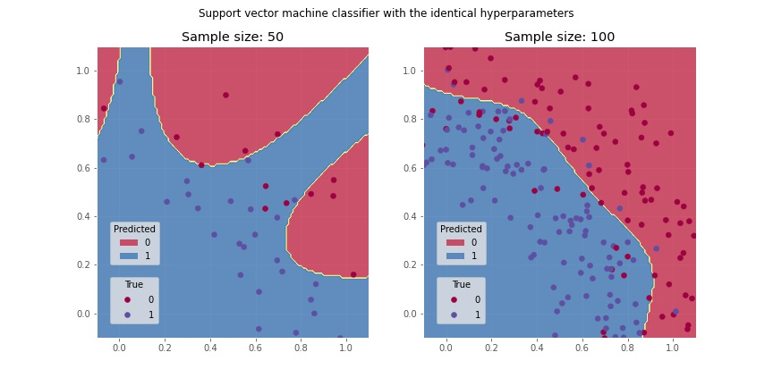

Figure 2.2: Using two data sets sampled from the same population two models are trained. One set of training data is larger than the other. The model with more data produces a more reasonable decision boundary, less influenced by individual data points. The model with less data is overfit, the model with more data is better generalised.

**Quality Questions**

Can more samples be collected?

Would more samples benefit the current model?

It’s important to note that it can be expensive, or challenging to obtain more training data.

Remember, we are trying to predict an unknown using a model trained on known outcomes.

Typically, we can get training data features easily - but labeling that data can be expensive. If all our data was labelled we wouldn’t need to build a prediction model!

Labeling the data can be expensive because it typically requires input from a person. If the person needs to be an expert or knowledgeable in a field this can be a bottleneck for obtaining lots of training data.

In addition, these labels aren’t guaranteed to always be completely correct, which can limit the best possible performance of our model, or increase the cost of getting accurate training data.

This means there are two points relevant to gathering more samples:

- Obtaining more unprocessed data - such as giving a survey to more participants
- Obtaining more labelled data - having an expert label survey responses based on agreed criteria and domain knowledge

We can improve our models performance if we do both of these.

There are some modelling techniques that can leverage both labelled and unlabeled data, but this is beyond the scope of this course. This is referred to as [semi-supervised learning](https://bdtechtalks.com/2021/01/04/semi-supervised-machine-learning/).

### 3.1.2 More Features

Generally, if we can give our model more information it will be able to learn a better informed relationship between features and labels.

Adding more features gives us “more pieces of the puzzle”, increasing the chance that our chosen model can pick up on a good way to predict what we want.

An increased number of features will allow more complex relationships to be learned.

Consider two similar individuals that we are trying to predict whether they will have ice-cream given the weather, time of year and so on. If we add a new feature that tells us whether the individual is lactose intolerant, this will be extremely useful for our model to learn from.

**How to obtain more features**

Without increasing the training data sample size there are a range of ways we can increase the *number* of features in the data.

- Collect them - ask more survey questions, observe more variables
  - Collecting more data may have a cost / response impact
- Create them - using existing features create new combinations and transformations from the original data
  - This can improve model performance in some model types but not in all cases
- Join them - link existing data from elsewhere to supplement the training data set, such as using geographic information and other data sets
  - Linking data needs to be carefully thought through to combine entities correctly and ethically.

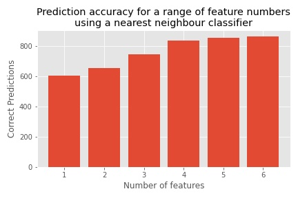

Figure 2.3: Using a simulated data set (n=1000) we can see the accuracy of the learned model improves with each feature added. In this example the first few features improve performance more than the later. Our model tends towards the true relationship in the data we will find it harder to improve performance with more features. Note, counting the number of overall correct predictions is not the best method for measuring performance, but more on that later.

We can measure the importance of features in a model for a range of model types. This can help tell us which are improving the model, and which aren’t. This will be covered in further detail within the interpretability module.

It is often difficult to tell whether a new feature added to a model will be useful, often we just need to try modelling with it to evaluate the performance with and without the features. This can cause a challenge when additional features require more cost, or more development resources.

**Quality Questions**

What features could be created from existing training data?

What supplementary data sources can we use?

Can we collect more features at the source?

Is there evidence that more features will not improve model performance?

We have now said that having more samples and more features can improve model performance, but which should we focus on?

The certain correct answer is “it depends”. There are no hard and fast rules for feature / model parameter / sample numbers, as they are all highly data and model dependent.

However, in general we should have more samples than features. Ideally multiples of samples per feature or model parameter. Anything more specific would be incorrect for a range of use cases. The best advice is to search for each model what is recommended in the statistics community, take it with a pinch of salt, and try it out for yourself.

## 3.2 Improve the model

We have up until now been intentionally fluffy with regards to what “Training a model with more data will **improve the model**” means in a practical sense.

“Improve the model” can mean a number of related but different things.

- Improve the predictive power of the model, how accurate it is
- Improve our confidence in the model, how certain we are about the predictions made
- Improve the robustness of the model, how good it will be when tackling unseen data

Providing the model with more data will have some effect on these three improvements, however, not all equally.

Adding more samples will typically improve all three aspects, but depending on the data and model may increase our confidence and robustness much more than the performance.

With a set number of samples, adding more features may improve the predictive performance of the model, but not necessarily improve our confidence in it.

It’s therefore important when we gather more data to improve the model’s performance we are clear about the **purpose** of this improvement. Hoping to improve the predictive performance may make us focus on getting new data in a different way than if we want a more robust model.

Again, these concepts are all related, and rarely tackled individually, but by looking at them individually we can better interrogate a predictive modelling system.

**Quality Questions**

What would be the purpose of further data gathering?

## 3.3 More of what?

In this section we have made quite a big assumption about the data we would gather if we could: it’s good data.

Not all data, or information for that matter, is created equally.

More samples or features can in some situations not improve model performance, and at worst actively make it worse.

There’s two general possibilities when we add “bad” data to our model.

- The data is uninformative
- The data is harmful

In the first instance, of uninformative data consider if we already have a strong representative sample. This new data collected doesn’t add more information the the model, it increases our confidence in the model marginally, but doesn’t change the model itself in a real way.

Or consider a new feature added to the training data. This new feature is really similar to an existing feature in the data set. It doesn’t tell us anything new about the relationships we are trying to model. If anything it makes it harder to determine whether the new or old feature is important, is it only one of them, is it both? [This blog further explains multicolinearity in a machine learning context](https://marinawyss.github.io/multicollinearity/).

And really, those two situations above are the best case scenario for unnecessarily adding more data.

We could add an additional feature that has no relationship with the outcome we are trying to predict. Our model may be able to notice this, or it may try to force a relationship, bringing down the model performance.

Even worse, we could be adding new data that was poorly labelled. If the data trained on is mislabeled (0’s labelled as 1’s or the other way) then we are giving the learning an algorithm an impossible task of learning what can’t be learned from the data. Even a small proportion of mislabeled data can drag down model performance substantially.

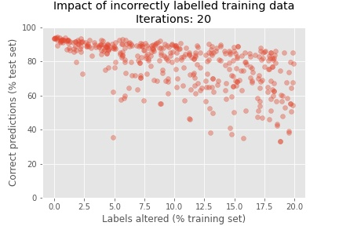

Figure 2.4: When small proportions of the training data’s labels are incorrect there can be large decreases in accuracy. This figure shows 20 iteration of the support vector classifier simulation, displaying a downward trend in accuracy with increased label incorrectness. In this example, the results show for less than 5%% incorrectly labelled data points the accuracy is decreased by more than 10%%. In this simulation all random elements are kept constant other than the flipping of labels each iteration.

Some of the most important data sets in AI have been found to have mislabeled training data. This will impact every model that has been trained on this data set. [For more information see this article about ImageNet](https://www.wired.com/story/foundations-ai-riddled-errors/).

Our new data may not even be representative of what we are trying to model. If we take snapshots over different time periods, different phenomena or populations we may limit our models ability to learn.

So were we accurate in saying more data improves our model?

Yes - now with the caveat:

> “Training a model with more **high quality** data will improve the model”

Our predictive model is a combination of the model selected and the data given to it. There’s no silver bullet in improving model performance, if we put “garbage in” we get “garbage out”.

If we want to ensure the predictive power, confidence and robustness of the model, we need to give it **quality data**.

**Quality Questions**

What is the quality of the data given to the model?

Are the labels used to train the model accurate?

Are the features of the data informative?

Are the samples representative of the population?

We have not discussed yet the impact of missing data (data points with some unknown values). The principles of having more data can be applied to this too. We want more **high quality** data to improve our models. Typically data with missing values, while inevitable, is not the highest quality possible.

There are broadly two options when handling missing data:

- Get rid of any data containing missing data (either removing a sample, or feature)
- Replace the missing value with a “sensible” estimate (we can do this in a wide range of ways)

In the first case, we lose information that is contained within the sample of feature that is not a missing value. This data lost may be representative and valuable to our model.

In the second case we are making a best guess at the missing value, but ultimately still a guess. By replacing the missing value we are assuming that the data point will conform to some trend we have chosen.

Both of these options will add bias to our model, so the best way to handle missing data is to have accurate data to begin with, the next best is to treat missing values with caution and investigate them, replacing them in a robust way.

**Quality Questions**

What is the prevalence of missing data used to train this model?

How were missing values handled, and how was bias minimised as a result?

## 3.4 Discussion

**Question**

What would need more data, a linear or non-linear model?

**Answer**

It’s difficult to say without specifying the exact non-linear model.

Typically non-linear models require more data (samples) in order to capture the non-linear relationships between features and the outcome.

The performance difference between a linear and non-linear model on the same data will depend on:

- how much more data the non-linear model needs to find the appropriate relationship
- how non-linear the relationships are

These concepts are difficult to work out before we test them!

[This blog gives some good approaches on how to reason the appropriate quantity of data for your needs](https://machinelearningmastery.com/much-training-data-required-machine-learning/). Long story short: there are no silver bullets.

# 4 Returning to Occam’s Razor

Recalling Occam’s Razor from the last chapter:

> “Entities should not be multiplied without necessity” - the simplest explanation is usually the correct one

This is a very reasonable rule of thumb, why over complicate something that likely has a simple explanation?

However, there is more ambiguity in this rule than first meets the eye when it comes to predictive modelling.

There often are not simple explanations for relationships we try to model. This means by using an overly simple model we may not get as much performance as out of a more complex choice.

We will first examine why we may want to choose a simple or complex model then explore how we can make decisions between the two.

Broadly, the choice between simple and complex models is a trade-off. When we typically gain something (such as interpretability), we will likely lose something else (such as accuracy), but it is not a clear cut relationship, or an either/or situation.

We are in a position to decide which direction to take our model complexity because, frankly, both will likely work.

## 4.1 Why Simple?

There are a wide range of enticing benefits to choosing “simple” models, with one notable drawback.

For now we are going to define a “simple” model as one which we as a human can comprehend. The focus of this module is not interpretability, but the concepts of model interpretability are highly relevant in this section.

A model which we can comprehend is one that produces relationships that can be understood by a human. A model with 10,000 coefficients describing a relationship is not simple, nor meaningful to an analyst. In practice this means:

- The number of coefficients/characteristic values of the model are not prohibitively large
- The number of features are not prohibitively large
- The learning algorithm is well understood

We will not make an evaluation on what “prohibitively large” means, but considering scale: 1 feature is good (but probably too simple), 10 is okay requiring some thinking, 100 would be difficult but with good documentation not impossible and 1000 near impossible.

We haven’t either specified what a “simple” model type is. Commonly understood as simple models:

- Linear / Logistic Regression
- Decision Trees

Commonly called complex:

- Ensemble Models (combinations of multiple predictors)
- Neural Networks

However, it is a mistake to classify a model’s complexity based just on it’s type. Looking at our three criteria for simple models, the model type only directly impacts the learning algorithm.

“Simple” model types become complex when given large numbers of features.

“Complex” model types can become simple when given fewer features and easier relationships to learn.

So now we get to the actual question at hand, why choose a simple model?

Simple models:

- Are typically easier to interpret and therefore audit and explain individual predictions
- *Can* be more robust, less likely to overfit to training data finding relationships that do not exist
- Can perform well with less training data compared to more complex models
- Can often approximate complex relationships well

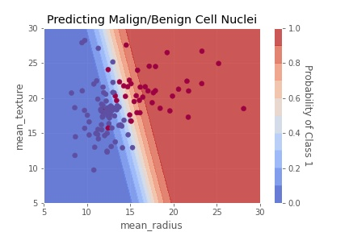

Figure 2.5: Using a logistic regression model with few variables we can clearly understand the relationship between the features and outcomes.

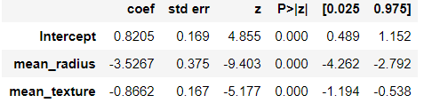

Figure 2.6: The simplicity of the model allows us to look at the model’s weights directly and understand them. We can do this because there are not too many features/coefficients and the model is well understood.

However, simple models:

- May miss more complex relationships between the data, causing poor performance

Assuming good practice has been followed we should never have only one model at the end of our analysis. We need models to compare with our preferred one to ensure it is actually any good. Simple models *need* to be part of this comparison.

**Quality Questions**

How does a *simple* baseline model perform on this task?

Can the features fed to the model be understood?

## 4.2 Why Complex?

If simple models always worked well then we wouldn’t need more complex models.

However, many real world predictive tasks are best represented by:

- complex relationships between features
- high dimensional combinations of features
- multiple levels of abstraction

For these types of problems, especially those with non-traditional data sources (text, audio, images), simple models simply cannot capture the complexity.

For our purposes now we will define a complex model as one which cannot easily be understood, because it falls into one of the following categories:

- High numbers of features in the data
- The resulting model’s characteristic values are too many
- The algorithm used to produce it is not well understood
- The features used to learn the relationship are not interpretable

Therefore more complicated models are a double edged sword, we can capture more information and squeeze out more predictive power, but this comes at a **cost**.

Our tolerance for this complexity cost is going to be different for every task, application, domain and stakeholder.

It is important to note here that the increase in complexity of a model isn’t only due to the model type chosen. Having more features, especially unclearly named / abstract values can make a simple model more complex.

For example, if we were to use a logistic regression model to classify images as boats or not boats, our first feature would be the top left pixel, the second would be the one to the right of that and so on. Is this mapping of an individual pixel values contribution to the outcome particularly clear? We may be able to get a coefficient from the model, but if our features (the individual pixels in this case) are not meaningful then the model is still complex.

What would it tell us if in one model pixel 47 was important, but in another model pixel 56 was twice as important? Not a huge deal.

**Measuring Model Complexity**

There are no single metrics that allow us to easily compare the complexity of a wide range of model types, the structures of different model families are too diverse.

However, an example heuristic could be the **number of parameters** in a model. For example, consider a 2 class problem with 5 features and 100 samples:

- Logistic Regression: $n\_features$ - 5 parameters
- Random Forest: $n\_trees \times avg\_tree\_depth$ ~ 100 parameters
- K-Nearest Neighbours: $n\_samples \times n\_features$ - 500 parameters
- Support Vector Machine: $n\_features \times (n\_classes * (n\_classes - 1) / 2)$ - 5 parameters

But this could be misleading, often a K-Nearest Neighbour model can be easy to interpret, it just needs to store all of the data used to train it, hence 500 parameters. There is no silver bullet for complexity measurement.

Some model types are better equipped to handle large numbers of features or combinations of features. Complex data of many features is referred to as “high-dimension”. Recall the **“Curse of Dimensionality”** from module 1. This refers to the idea that it is hard to model high dimensional data, not all models are able to do it and not all results from it are easy to understand.

In predictive modelling the “Curse of Dimensionality” is partly a curse and partly a blessing. We can take advantage of this high dimensionality data, but we do need to be aware of the risks that it brings.

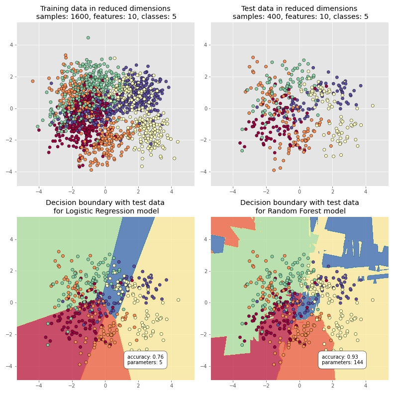

Figure 2.7: Comparing a simple and a complicated model on a synthetic multiclass classification task, logistic regression and random forest respectively. The complex model performs significantly better, but has many more parameters which will be challenging to understand. In the random forest model we will actually have 20 different decision trees to understand if we want to fully comprehend why a prediction was made. In our reduced dimension space the decision boundaries are less straight forward than when compared to the logistic regression.

So, to answer the question in this section title, why would we ever want to choose a complex model to perform a predictive modelling task? There’s a good chance it will just perform better than a simple problem, picking up stronger relationships than a simple model, which will in turn lead to more correct predictions. If accuracy is important to us, then this is very tempting.

**Quality Questions**

How does a more complex model type perform on this task?

How does the inclusion of more complex features change model performance?

It’s important to note here that there is not a binary choice between simple and complex. In fact, simple and complex are relative terms.

We rarely state that a certain model created is simple, but rather it may be more simple than another model explored.

Within highly complex models, we can still have some that are easier to understand, with fewer parameters and features than others.

Remember, the model is a combination of the learning algorithm chosen (model type), and the data used to train it (the features). Both the model type and features can be made to be more or less complex depending on our need.

## 4.3 What do we value?

To summarise the challenge to far:

Simpler models:

- Are easier to understand
- Can generalize well on small data sets
- Will miss complex relationships

Complex models:

- Are more challenging to understand
- Often perform better

Which to pick overall, or between specific models therefore has little to do with the inherent models themselves.

What really matters in this decision is what we value from our model.

**This is not a decision that the analyst can make in isolation.**

Complexity is at minimum two components: model type and feature complexity (number of features and how well understood they are).

As referred to in the previous module we now have an optimisation problem. We need to decide on what the goals and constraints are.

We cannot both get the **highest model predictive performance** (accuracy, specificity or whatever our chosen metric is), and have the **simplest model possible**.

We can try to find that balance between simplicity and performance, but this is challenging without a strategy.

To more easily solve this problem we need to fix one of our objectives:

- Set a minimum predictive performance and find the simplest model that gets this performance level
- Find the best performing model that meets simplicity constraints

We will not just pick a performance number out of thin air (get 99% accuracy minimum), but rather first experiment to work out what is achievable in the problem area.

To do either of the above strategies we need to understand in detail what the requirements are from the model commissioner / business area.

Is there a minimum level of performance required? There will always be errors in a prediction model, so what is our tolerance for risk and incorrect predictions? Considering reputational damage, resourcing and knock on effects are important in coming to this conclusion.

Are there hard limits on the simplicity of the model? Will every prediction need to be fully understood? Who needs to understand the model (just the analyst and the assurer, or non-specialists, the public)? Is the model being used for inference and prediction? Do the predictions need to be linked directly or indirectly to understandable features?

Whether we can even use a complex model may be limited by factors out of the analyst’s control, such as quantity of data available. This too will be a constraint on the simplicity of a model. If we use complex models on small data sets we are setting ourselves up for overfitting / poorly generalised models.

**Quality Questions**

What is the minimum predictive performance required?

What constraints on simplicity do we have?

How much data do we have access to train with?

What do we lose by using a more complex model (something is always lost)?

It may be that in some problems there are no constraints on simplicity, and we can therefore create a complex model that predicts as much as possible. Even in this case it is crucial that we document what our simplicity constraints were.

Alternatively, there may be no (or an easy to meet) minimum predictive performance. The model may be used in a supplementary non-critical context where it is just less damaging to make incorrect predictions. We obviously want the model to perform as well as possible, but we can focus more in this problem on having a simple and easy to understand model. Again, we need to record any decisions that are made around goals for a model.

### 4.3.1 In Practice

We need to be able to inform the model commissioner about what is achievable in this problem. The analyst needs to set reasonable expectations for model performance so the commissioner can determine what appropriate complexity goals are for their business problem.

This requires initial experimentation before the modelling process starts in earnest.

So where does this leave us? Simple models can be great, but only if it is possible to represent the phenomenon we are trying to model in a simple way. Once our modelling goals have been established we can begin creating and comparing models.

This makes us want to use **the simplest model that can perform well on the problem**. A common method to do this is:

- Start with a very simple model, increase it’s complexity until a desired performance level is achieved
  - If a simple model will not work for our task, start with a complex model and reduce features / change type until desired simplicity is found

If a complex model has been chosen, it is crucial that it has been compared to simpler models and the conclusion of using a more complex model meets the goals set for the modelling task.

If a simple model has been chosen, it’s key that it has been compared to more complex models and that the simplicity is aligned with the goals of the modelling task.

**Quality Questions**

Have the decisions on modelling requirements been documented?

Has the final model been compared with more/less complex models?

Does the final model meet the modelling requirements on performance and simplicity?

## 4.4 Discussion

**Question**

Order the following applications in order (most to least) of how important simplicity is to us:

- Predicting product purchase probability
- Predicting counts of trees in a picture of a forest
- Predicting heart attacks

**Answer**

1. Predicting heart attacks
- Having a “simple” model is very useful as it will allow risks to be understood better
- If the model is wrong we need to understand it well
- If our model is wrong there will be life altering consequences
2. Predicting product purchase probability
- While not crucial, a simple model will help us understand what drives purchases
- The impact of incorrect prediction is real but not substantial
3. Predicting counts of trees in a picture of a forest
- It will be diffict to model this simply
- The impact of incorrect classification exists, but is minor

# 5 No Free Lunch

The “No Free Lunch Theorem” is an important idea in mathematics, optimisation problems and particularly machine learning / predictive modelling.

The idea is a play on the saying “there’s no such thing as a free lunch”, which implies if you are being offered a free lunch there’s probably a hidden cost somewhere.

In a more formal definition for predictive modelling:

> “If an algorithm performs well on a certain class of problems then it necessarily pays for that with degraded performance on the set of all remaining problems”

So what does this mean? If an algorithm (type of model design choice) performs well on a task, then it will perform badly on other tasks.

This has significant and reoccurring consequences for our modelling problems.

If approach A works well in task 1, there are other tasks for which approach A will not be particularly good.

This way of thinking about the approaches does assume we aren’t making methodological errors or in our algorithms.

Some consequences that follow from this theorem:

- Strong performance in a given task will not **necessarily** translate to a different task.
- Suitability for a given task requires unsuitability for other tasks.
- We cannot have “favourite” approaches or models, they will not work well for every problem.
- There are no *one size fits all* approaches for modelling.
- Other approaches than our chosen one will work on our task to varying degrees.

What this doesn’t mean is that previous work in a domain has no value. A good model approach for predicting ice-cream sales using the weather and personal information may work really well for predicting ice-lolly sales in the same area. That same modelling approach may not be appropriate for predicting credit card fraud within the same group of people.

An important point is that a **range** of approaches need to be considered and tested, because our chosen approach that we like may not be the most suitable. It is challenging to determine if an approach is going to work well before we apply it.

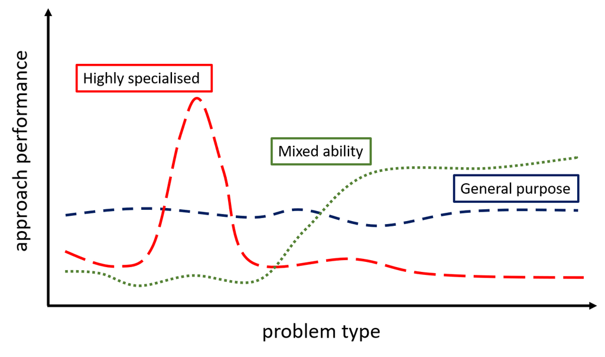

Figure 2.8: Different approaches perform better than others in different contexts. It’s useful to be aware of whether we are using a highly specialised approach or a more general one. This will impact how we can assure the approach.

Further to this, the distribution of how good an approach is can be distributed in a range of ways across different tasks. Some approaches are well rounded but never the best in problems. Other algorithms are really good for certain problems, and poor in others. Knowledge about the learning algorithms is helpful here to decide which is going to be helpful for us.

As with most of predictive modelling, the way we can know if an approach, learning algorithm, processing technique or data set, is good by trying it and documenting the results for comparison.

This is a key reason why we should avoid either automating machine learning design processes, or try to tackle prediction tasks with a one-size fits all approach. We will likely miss out on relatively easy performance increases, or miss opportunities for making our models simpler.

Being familiar with advances in the domain is helpful in understanding what a good specialist approach to a problem may be.

Often, how complex an approach is, the more complex it is, which may limit what we want to consider.

**Quality Questions**

What range of approaches have been taken in addressing this problem? What was their performance?

Why was this learning algorithm chosen?

What other work in similar problems has been completed and how did this influence the modelling approach?

# 6 Specification Gaming

When using a learning algorithm the patterns found may not be what we want. If a learning algorithm is used without care, a model can be learned which does not incorporate meaningful relationships. If we do not robustly test our models this can occur without us noticing, with catastrophic consequences.

We are trying to optimise a process - our algorithms will often choose the path of minimum resistance, in effect taking a “shortcut” or “cheating” the system to maximise whatever we have tasked it with.

If the real relationship between some training data and labels is complex, and there is a simple, bad explanation that will be found instead.

This is a larger problem in AI, but can also be applied to predictive modelling.

We are more at risk from this problem when:

- We cannot explain our model simply
- Our training data is highly complex (particularly for high dimensional data such as text / images)
- Our learning algorithm is transforms data into spaces we cannot understand (think: neural networks, embeddings, metric spaces)
- The objective we are trying to maximise is oversimplified

In the case of predictive modelling, specification gaming often manifests itself as a form of “overfitting”.

## 6.1 Examples

We will look at some related examples in machine learning to get a feel for the challenge, then address approaches to avoiding this phenomenon.

Many of the examples here have been collected from the [DeepMind Safety Research](https://medium.com/@deepmindsafetyresearch) team, further examples can be found [on this google spreadsheet](https://docs.google.com/spreadsheets/u/1/d/e/2PACX-1vRPiprOaC3HsCf5Tuum8bRfzYUiKLRqJmbOoC-32JorNdfyTiRRsR7Ea5eWtvsWzuxo8bjOxCG84dAg/pubhtml).

### 6.1.1 Maximise Velocity

In this task the researchers intended to learn a model that can walk quickly. Therefore they chose to learn a model that maximises the speed of the agent.

It is much simpler for the agent to learn to become tall and fall over, exploiting the acceleration from gravity, rather than learn the really complicated task of running.

The model has done incredibly well on the terms it has been asked to perform. These terms are not what the researcher intended leading to a model which cannot be used for the intended task.

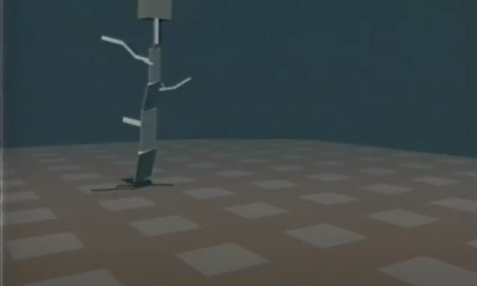

Figure 2.9: The agent has found an easy way to maximise velocity.

In this example it’s simple to see what the issue was, [we can thankfully watch the agent do what it learned.](https://www.youtube.com/watch?v=TaXUZfwACVE&list=PL5278ezwmoxQODgYB0hWnC0-Ob09GZGe2&index=9) This is not always the case for predictive modelling.

To fix this the researchers will have changed how they reward the agent for good performance. Instead of just asking for “maximum velocity”, they could have added constraints on the height of the agent, or the mechanics of it’s allowed movement. It could reward small angular momentum for example as well as encourage high overall velocity.

We need to keep in mind whenever we are building a system **that what we are telling our model to optimise is actually what we are expecting**.

### 6.1.2 Detecting Pneumonia in Chest X-Rays

Deep learning has become an increasingly common approach to predictive modelling in high dimensionality data, such as images and text.

This example uses convolutional neural networks (CNNs, frequently used for image classification) to predict whether a patient has pneumonia based on a x-ray image.

Instead of learning to detect pnemonia itself the model instead learned an unexpected proxy for pnemonia: the type of x-ray machine used. Different medical departments and hospitals from which the data was obtained used different machines. Each department had a different prevelance of pnemonia cases.

Patients with pnemonia were more likely to be in certain hospital departments, rather than others, depending on whether they had pnemonia or not.

The differences in x-ray machines could be detected relatively easily (for example, the average pixel values may be different between each model). This was then predicted rather than whether the patient had pnemonia.

Testing within this data set produced good results, however, the model would not work well for images from other x-ray machines as the model **did not learn the phenomenon expected**, instead it learnt a proxy for pnemonia: the x-ray machine type.

For more information on this please see the original paper: [Variable generalization performance of a deep learning model to detect pneumonia in chest radiographs: A cross-sectional study](https://journals.plos.org/plosmedicine/article?id=10.1371/journal.pmed.1002683).

This was a case of overfitting to the training set, but also an issue of experimental design and evaluation.

The specification gaming in this case could have been avoided in a number of ways (preferably a combination).

- Testing the model on data from machines not part of the training data
- Using a single x-ray machine for all training data
- Using a range of x-ray machines, but ensuring the classes (yes-pnemonia, no-pnemonia) are balanced for each machine, similar number of each
- Normalising the data appropriately, removing any differences in x-ray machine that can be found by the model. In the example case, standardising and cropping the images would have been useful.

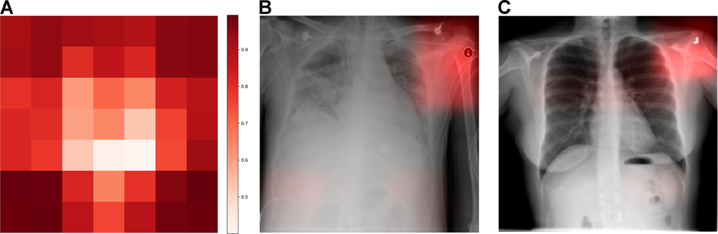

Figure 2.9: Using a technique to explore regions of interest, an area of an image which contributes significantly to a prediction, the researchers were able to see that the network was looking at the corner of the x-ray image, rather than at the lungs at all. A - an averaged heatmap of where the model is looking for all images. B & C example images with red where the model is focusing on. Image obtained from the paper linked above.

In this case the objective (maximise correct predictions) was appropriate, but the data given to perform this task was flawed, and the evaluation approach was not robust. The model would likely never have worked out the true relationship, why would it need to given this other easier relationship?

From the paper itself:

> “We note that the CNN has learned to detect a metal token that radiology technicians place on the patient in the corner of the image field of view at the time they capture the image”

Finding out the problem in this case was harder because it was challenging to understand **what** the model was predicting. There were not obvious feature coefficients to explore, but other, harder explanatory methods needed to be used. Being able to understand **why** the model has made a prediction is a key assurance step if the prediction has high impact (predicting a disease being a very high potential impact).

## 6.2 Avoiding Specification Gaming

Somewhat inherent in the specification gaming is it’s unexpected nature. The analyst rarely intends to create a model that finds an unwanted shortcut.

However, this doesn’t stop the problem rearing it’s head. By following robust experimental design and quality assurance processes we can prevent it occurring in the first place or catch it when it does happen.

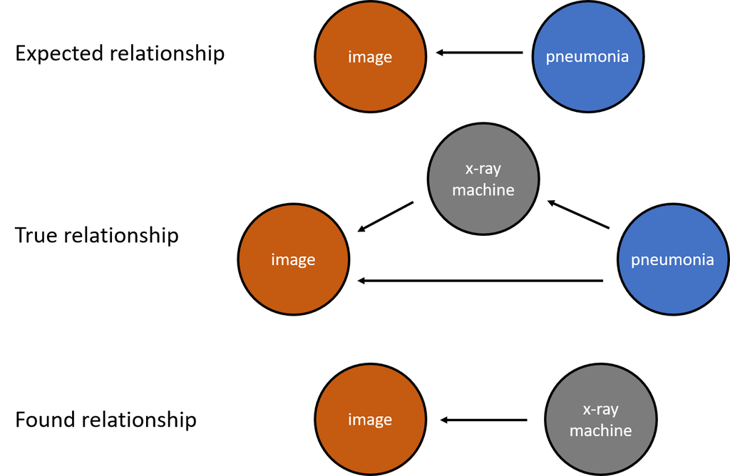

Figure 2.10: If we do not account for causal relationships we run the risk of our model learning an unintended relationship.

There are a wide range of other methodological problems that can occur in our model, which will be discussed in Module 4: Avoiding (Statistical) bias.

Suggested methods for avoiding specification gaming:

- Unambiguous goals, clearly aligned with modelling goals
- Exploration of counterfactual relationships that are possible to learn, using domain knowledge
- Representative training data
- Robust data preprocessing
  - Standardising data to make all sample comparable
  - Exploration of latent variables
  - Handling of confounding variables

Methods for checking for specification gaming:

- Fully unseen test data to evaulate generalisability
- Understandable models / explainable decisions

**Quality Questions**

What evidence is there that the relationship learned is the one intended?

What parts of the data are important to how a model came to this decision?

How has this data been pre-processed?

## 6.3 Discussion

**Question**

If you were [King Midas](https://en.wikipedia.org/wiki/Midas#:~:text=The%20most%20famous%20King%20Midas,touch%2C%20or%20the%20Midas%20touch.) who wished everything he touched would turn to gold, what extra conditions would you have added to your wish?

**Answer**

- Only turn things to gold that you conciously want to be gold and touch
- Unable to turn living beings into gold
- Unable to turn water/food into gold

# 7 Summary

In this model we have looked at common knowledge in predictive modelling, things that are helpful to know about when assuring the quality of a model at a high level.

We explored a number of concepts which are at play when designing predictive models. These led us to questions that will be useful to check the quality of an analysis.

The main concepts covered in this chapter are:

- Giving our model more data, and how it can help improve performance and robustness.
- Occam’s razor and how it relates to the performance / understandability tradeoff.
- No Free Lunch theorem, and why it’s important to explore a range of modelling options.
- Specification gaming, and how it can sneak into our models if robust experimental design isn’t conducted.

We will explore some of the concepts in more technical depth within Module 4: Avoiding (Statistical) Bias, Module 5: Model Interpretability and Module 7: Further Good Practice in Modelling.

In the next chapter, we will explore ethical applications of predictive modelling, the various considerations we need to be aware of when assuring a model’s ethical implications.